# Kmeans

```python
import numpy as np #数维度数组与矩阵运算
import xlrd #读取excel
import pandas as pd #分析结构化数据
from matplotlib import pyplot as plt #可视化


io = r'E:/Python/机器学习test/game_ori.xlsx.'
df = pd.read_excel(io, sheet_name = "Sheet1")
print(type(df))
df.head(10)
```

```
<class 'pandas.core.frame.DataFrame'>
```

|  | user_id | last_login_to_now | duration | level_end | os_corr | active_days | avg_session_cnt | is_payer |
| --- | --- | --- | --- | --- | --- | --- | --- | --- |
| 0 | iggve | 0 | 379 | 32 | 0 | 246 | 2.8 | 1 |
| 1 | 10a5a | 575 | 0 | 1 | 0 | 1 | 2.0 | 0 |
| 2 | osgre | 81 | 200 | 28 | 0 | 63 | 8.4 | 1 |
| 3 | hgvdz | 0 | 485 | 78 | 0 | 474 | 15.6 | 1 |
| 4 | 6fc22 | 520 | 67 | 29 | 0 | 46 | 6.6 | 0 |
| 5 | dea49 | 589 | 0 | 4 | 0 | 1 | 3.0 | 0 |
| 6 | gafdb | 0 | 153 | 39 | 0 | 151 | 9.2 | 1 |
| 7 | 68be8 | 575 | 0 | 2 | 0 | 1 | 2.0 | 0 |
| 8 | gdewm | 0 | 261 | 61 | 0 | 255 | 7.4 | 1 |
| 9 | 7b830 | 316 | 263 | 22 | 0 | 16 | 6.3 | 0 |

```python
df.describe()
```

|  | last_login_to_now | duration | level_end | os_corr | active_days | avg_session_cnt | is_payer |
| --- | --- | --- | --- | --- | --- | --- | --- |
| count | 4041.000000 | 4041.000000 | 4041.000000 | 4041.000000 | 4041.000000 | 4041.000000 | 4041.000000 |
| mean | 353.132888 | 136.741896 | 23.656521 | 0.157882 | 77.943578 | 6.305444 | 0.465726 |
| std | 231.699546 | 171.793267 | 24.139945 | 0.364675 | 127.017118 | 5.883220 | 0.498886 |
| min | 0.000000 | 0.000000 | 1.000000 | 0.000000 | 1.000000 | 1.100000 | 0.000000 |
| 25% | 109.000000 | 1.000000 | 2.000000 | 0.000000 | 2.000000 | 2.100000 | 0.000000 |
| 50% | 440.000000 | 52.000000 | 16.000000 | 0.000000 | 15.000000 | 4.300000 | 0.000000 |
| 75% | 575.000000 | 233.000000 | 38.000000 | 0.000000 | 93.000000 | 8.200000 | 1.000000 |
| max | 590.000000 | 591.000000 | 149.000000 | 1.000000 | 590.000000 | 69.700000 | 1.000000 |

```python
st_data=df.loc[:,["last_login_to_now","duration","level_end","os_corr" ,"active_days" ,"avg_session_cnt" ,"is_payer"]]
del st_data["is_payer"]
st_data.head()
```

|  | last_login_to_now | duration | level_end | os_corr | active_days | avg_session_cnt |
| --- | --- | --- | --- | --- | --- | --- |
| 0 | 0 | 379 | 32 | 0 | 246 | 2.8 |
| 1 | 575 | 0 | 1 | 0 | 1 | 2.0 |
| 2 | 81 | 200 | 28 | 0 | 63 | 8.4 |
| 3 | 0 | 485 | 78 | 0 | 474 | 15.6 |
| 4 | 520 | 67 | 29 | 0 | 46 | 6.6 |

```python
from sklearn import preprocessing
#Z-Score标准化
#建立StandardScaler对象
zscore = preprocessing.StandardScaler()
# 标准化处理
data_zs_array = zscore.fit_transform(st_data)
df_data_zs=pd.DataFrame(data_zs_array,columns=["last_login_to_now1","duration1","level_end1","os_corr1" ,"active_days1" ,"avg_session_cnt1"])
df_data_zs.head()
```

|  | last_login_to_now1 | duration1 | level_end1 | os_corr1 | active_days1 | avg_session_cnt1 |
| --- | --- | --- | --- | --- | --- | --- |
| 0 | -1.524287 | 1.410347 | 0.345672 | -0.432991 | 1.323264 | -0.595911 |
| 1 | 0.957682 | -0.796066 | -0.938665 | -0.432991 | -0.605848 | -0.731908 |
| 2 | -1.174653 | 0.368268 | 0.179951 | -0.432991 | -0.117665 | 0.356066 |
| 3 | -1.524287 | 2.027444 | 2.251463 | -0.432991 | 3.118520 | 1.580037 |
| 4 | 0.720277 | -0.406014 | 0.221382 | -0.432991 | -0.251521 | 0.050073 |

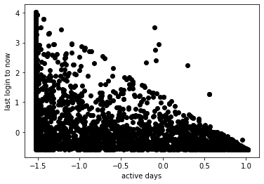

```python
%matplotlib inline
X=df_data_zs.loc[:,["last_login_to_now1","active_days1"]]
#可视化
plt.scatter(X["last_login_to_now1"],X["active_days1"],c='black')
plt.xlabel('active days')
plt.ylabel('last login to now')
plt.show()
```

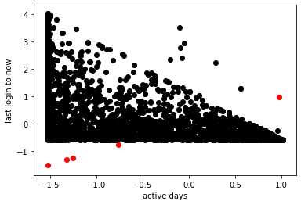

```python
#簇的个数
K=5
# 随机选择观察值作为簇心
Centroids = (X.sample(n=K))
plt.scatter(X["last_login_to_now1"],X["active_days1"],c='black')
plt.scatter(Centroids["last_login_to_now1"],Centroids["last_login_to_now1"],c='red')
plt.xlabel('active days')
plt.ylabel('last login to now')
plt.show()
```

```python
print(df_data_zs.isnull().any())
```

```
last_login_to_now1    False
duration1             False
level_end1            False
os_corr1              False
active_days1          False
avg_session_cnt1      False
dtype: bool
```

```python
from sklearn.cluster import KMeans
n_clusters=4
kmeans=KMeans(n_clusters=n_clusters)
kmeans.fit(df_data_zs)
centers = kmeans.cluster_centers_
centers
```

```
array([[-0.77642828,  0.44135548,  0.34858349, -0.43299149,  0.07629577,
         0.29826454],
       [-0.02956341, -0.11006713, -0.08331419,  2.30951419, -0.20365139,
        -0.16846223],
       [ 0.82851448, -0.6713215 , -0.68690869, -0.43299149, -0.55972291,
        -0.47885474],
       [-1.37047836,  1.75492571,  2.02428007,  0.07934473,  2.3473077 ,
         1.40357767]])
```

参数 说明 n-cluster 分类簇的数量 max_iter 最大的迭代次数 n_init 算法的运行次数 init 接收待定的string。kmeans++表示该初始化策略选择的初始均值向量之间都距离比较远，它的效果较好； random表示从数据中随机选择K个样本最为初始均值向量；或者提供一个数组，数组的形状为（n_cluster,n_features）， 该数组作为初始均值向量。 precompute_distance 接收Boolean或者auto。表示是否提前计算好样本之间的距离，auto表示如果nsamples*n>12 million，则不提前计算。 tol 接收float，表示算法收敛的阈值。 N_jobs 表示任务使用CPU数量。 random_state 表示随机数生成器的种子。 verbose 0表示不输出日志信息；1表示每隔一段时间打印一次日志信息。如果大于1，打印次数频繁。

```python
arr=np.insert(centers,0,values=range(n_clusters),axis=1)
center_pd=pd.DataFrame(arr,columns=["cluster_No.","last_login_to_now","duration","level_end","os_corr" ,"active_days" ,"avg_session_cnt" ])
center_pd
```

|  | cluster_No. | last_login_to_now | duration | level_end | os_corr | active_days | avg_session_cnt |
| --- | --- | --- | --- | --- | --- | --- | --- |
| 0 | 0.0 | -0.776428 | 0.441355 | 0.348583 | -0.432991 | 0.076296 | 0.298265 |
| 1 | 1.0 | -0.029563 | -0.110067 | -0.083314 | 2.309514 | -0.203651 | -0.168462 |
| 2 | 2.0 | 0.828514 | -0.671321 | -0.686909 | -0.432991 | -0.559723 | -0.478855 |
| 3 | 3.0 | -1.370478 | 1.754926 | 2.024280 | 0.079345 | 2.347308 | 1.403578 |

```python
#返回每个分类的个数 np.array计数
kind,count=np.unique(kmeans.labels_,return_counts=True)
print(kind)
print(count)
```

```
[0 1 2 3]
[1167  553 1866  455]
```

```python
#打印出每个序号样本对应的类别分类， 0,1,2,3，和上面的中心点一一对应
km_lables=pd.DataFrame(kmeans.labels_,columns=["cluster_No."])
df_final=df.join(km_lables)
df_final.head(100)
```

|  | user_id | last_login_to_now | duration | level_end | os_corr | active_days | avg_session_cnt | is_payer | cluster_No. |
| --- | --- | --- | --- | --- | --- | --- | --- | --- | --- |
| 0 | iggve | 0 | 379 | 32 | 0 | 246 | 2.8 | 1 | 0 |
| 1 | 10a5a | 575 | 0 | 1 | 0 | 1 | 2.0 | 0 | 2 |
| 2 | osgre | 81 | 200 | 28 | 0 | 63 | 8.4 | 1 | 0 |
| 3 | hgvdz | 0 | 485 | 78 | 0 | 474 | 15.6 | 1 | 3 |
| 4 | 6fc22 | 520 | 67 | 29 | 0 | 46 | 6.6 | 0 | 2 |
| 5 | dea49 | 589 | 0 | 4 | 0 | 1 | 3.0 | 0 | 2 |
| 6 | gafdb | 0 | 153 | 39 | 0 | 151 | 9.2 | 1 | 0 |
| 7 | 68be8 | 575 | 0 | 2 | 0 | 1 | 2.0 | 0 | 2 |
| 8 | gdewm | 0 | 261 | 61 | 0 | 255 | 7.4 | 1 | 0 |
| 9 | 7b830 | 316 | 263 | 22 | 0 | 16 | 6.3 | 0 | 0 |
| 10 | 0f53a | 582 | 0 | 1 | 1 | 1 | 2.0 | 0 | 1 |
| 11 | 49dd0 | 484 | 95 | 7 | 0 | 2 | 2.5 | 0 | 2 |
| 12 | ibegc | 9 | 315 | 3 | 0 | 24 | 1.7 | 1 | 0 |
| 13 | 97d24 | 569 | 5 | 7 | 0 | 5 | 3.6 | 0 | 2 |
| 14 | f066d | 546 | 42 | 39 | 0 | 43 | 36.1 | 1 | 0 |
| 15 | e6197 | 0 | 572 | 139 | 0 | 571 | 17.2 | 1 | 3 |
| 16 | d2279 | 563 | 25 | 18 | 0 | 17 | 2.2 | 0 | 2 |
| 17 | aa3ff | 575 | 0 | 1 | 0 | 1 | 2.0 | 0 | 2 |
| 18 | b1464 | 575 | 0 | 1 | 0 | 1 | 3.0 | 0 | 2 |
| 19 | 8ad65 | 508 | 71 | 34 | 0 | 53 | 6.6 | 1 | 2 |
| 20 | 85afc | 500 | 81 | 36 | 1 | 64 | 8.1 | 1 | 1 |
| 21 | f44b3 | 566 | 18 | 15 | 1 | 14 | 2.6 | 0 | 1 |
| 22 | 4215c | 589 | 0 | 5 | 1 | 1 | 3.0 | 0 | 1 |
| 23 | cff6e | 576 | 1 | 1 | 0 | 2 | 1.5 | 0 | 2 |
| 24 | vgqdz | 62 | 431 | 50 | 0 | 193 | 7.2 | 1 | 0 |
| 25 | 3b556 | 0 | 586 | 87 | 0 | 582 | 21.9 | 1 | 3 |
| 26 | relpn | 193 | 164 | 34 | 0 | 134 | 2.8 | 1 | 0 |
| 27 | 7a5bb | 578 | 1 | 1 | 0 | 2 | 1.5 | 0 | 2 |
| 28 | e99ac | 583 | 1 | 1 | 0 | 3 | 1.6 | 0 | 2 |
| 29 | 55a38 | 349 | 237 | 40 | 0 | 112 | 8.5 | 1 | 0 |
| ... | ... | ... | ... | ... | ... | ... | ... | ... | ... |
| 70 | gvefv | 43 | 384 | 24 | 0 | 31 | 2.9 | 1 | 0 |
| 71 | f01d1 | 590 | 0 | 2 | 0 | 1 | 3.0 | 0 | 2 |
| 72 | vehgm | 0 | 444 | 46 | 0 | 207 | 20.2 | 1 | 3 |
| 73 | edd0f | 562 | 12 | 18 | 0 | 12 | 3.0 | 0 | 2 |
| 74 | c9c9b | 579 | 0 | 2 | 0 | 1 | 3.0 | 0 | 2 |
| 75 | ac79d | 581 | 4 | 16 | 0 | 5 | 12.2 | 0 | 2 |
| 76 | mfddv | 140 | 8 | 17 | 0 | 8 | 10.3 | 1 | 0 |
| 77 | 279de | 585 | 0 | 1 | 0 | 1 | 3.0 | 0 | 2 |
| 78 | 48971 | 556 | 23 | 16 | 0 | 14 | 3.7 | 0 | 2 |
| 79 | kgyea | 80 | 122 | 54 | 0 | 95 | 22.8 | 1 | 0 |
| 80 | defwu | 431 | 7 | 22 | 0 | 8 | 13.1 | 1 | 2 |
| 81 | gzeih | 364 | 44 | 38 | 0 | 45 | 18.8 | 1 | 0 |
| 82 | c9ecc | 488 | 89 | 7 | 0 | 3 | 1.6 | 0 | 2 |
| 83 | e2d54 | 364 | 207 | 36 | 0 | 53 | 5.5 | 0 | 0 |
| 84 | a1e71 | 583 | 0 | 7 | 1 | 1 | 2.0 | 0 | 1 |
| 85 | befpd | 135 | 294 | 76 | 0 | 428 | 17.4 | 1 | 3 |
| 86 | 74387 | 0 | 582 | 96 | 0 | 494 | 21.8 | 0 | 3 |
| 87 | 26c8c | 584 | 1 | 3 | 0 | 2 | 2.5 | 0 | 2 |
| 88 | f3618 | 269 | 304 | 54 | 0 | 283 | 11.5 | 1 | 3 |
| 89 | f8e16 | 585 | 0 | 1 | 1 | 1 | 2.0 | 0 | 1 |
| 90 | d52dd | 572 | 1 | 5 | 0 | 2 | 2.0 | 0 | 2 |
| 91 | e155e | 590 | 0 | 1 | 1 | 1 | 2.0 | 0 | 1 |
| 92 | a89e0 | 50 | 525 | 35 | 0 | 186 | 6.6 | 1 | 0 |
| 93 | f5ed6 | 332 | 239 | 41 | 0 | 97 | 7.5 | 1 | 0 |
| 94 | kegvd | 0 | 505 | 99 | 0 | 505 | 16.4 | 1 | 3 |
| 95 | 2a307 | 586 | 0 | 1 | 1 | 1 | 2.0 | 0 | 1 |
| 96 | d5d78 | 333 | 244 | 31 | 1 | 77 | 4.9 | 1 | 1 |
| 97 | 0aec9 | 488 | 89 | 19 | 0 | 22 | 2.9 | 1 | 2 |
| 98 | lgoen | 102 | 234 | 45 | 0 | 178 | 9.2 | 1 | 0 |
| 99 | 0ef02 | 585 | 1 | 1 | 0 | 2 | 1.5 | 0 | 2 |

100 rows × 9 columns

```python
#导出到excel
df_final.to_excel('clustering sample.xlsx',index = False)
```

```python
from sklearn.metrics import silhouette_samples,silhouette_score
#调用轮廓系数分数，silhouette_avg生成所有样本点轮廓系数的均值
#需要输入两个参数，特征矩阵X与聚类完毕的标签
silhouette_avg = silhouette_score(df_data_zs,kmeans.labels_)
#打印现有簇数量下，轮廓系数是多少
print("For n_clusters =", n_clusters,
      "The average silhouette_score is :", silhouette_avg)
```

```
For n_clusters = 4 The average silhouette_score is : 0.4706525127953229
```

```python
#调用silhouette_samples，返回每个样本点的轮廓系数，就是横坐标
sample_silhouette_values = silhouette_samples(df_data_zs, kmeans.labels_)
print(sample_silhouette_values)
```

```
[0.28766081 0.82650946 0.44604411 ... 0.36701681 0.36968591 0.82680151]
```

```python
#碎石图的inertia值
kmeans.inertia_
```

```
7953.511612694995
```

```python
Inertias_list = []
score_list=[]
from sklearn.metrics import silhouette_samples,silhouette_score
for cluster in range(2,10):
    kmeans = KMeans(n_jobs = -1, n_clusters = cluster)
    kmeans.fit(df_data_zs)
    silhouette_avg= silhouette_score(df_data_zs,kmeans.labels_)
    Inertias_list.append(kmeans.inertia_)
    score_list.append(silhouette_avg)

    print("for cluster number is :",cluster,"\n",
          "The SSE is :",kmeans.inertia_,"\n",
          "The average silhouette_score is :",silhouette_avg,"\n","_______________________")

print(Inertias_list)
print(type(Inertias_list))
```

```
for cluster number is : 2
 The SSE is : 13791.764482825734
 The average silhouette_score is : 0.4627219584162551
 _______________________
for cluster number is : 3
 The SSE is : 10672.509482066951
 The average silhouette_score is : 0.4054438288402542
 _______________________
for cluster number is : 4
 The SSE is : 7953.517354263786
 The average silhouette_score is : 0.4704243659729215
 _______________________
for cluster number is : 5
 The SSE is : 7006.504510375431
 The average silhouette_score is : 0.47451635708542544
 _______________________
for cluster number is : 6
 The SSE is : 6145.1634848724925
 The average silhouette_score is : 0.48878744017323017
 _______________________
for cluster number is : 7
 The SSE is : 5353.24921857392
 The average silhouette_score is : 0.46274721029914856
 _______________________
for cluster number is : 8
 The SSE is : 4810.558332727086
 The average silhouette_score is : 0.4711171453176167
 _______________________
for cluster number is : 9
 The SSE is : 4414.889119247402
 The average silhouette_score is : 0.4650892231761025
 _______________________
[13791.764482825734, 10672.509482066951, 7953.517354263786, 7006.504510375431, 6145.1634848724925, 5353.24921857392, 4810.558332727086, 4414.889119247402]
<class 'list'>
```

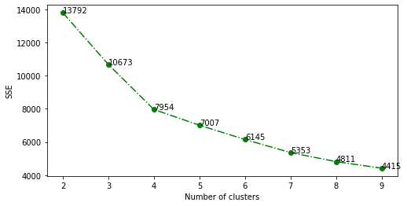

```python
# 绘制图形
Cluster=range(2,10)
frame = pd.DataFrame({'Cluster':Cluster, 'Inertia':Inertias_list})
from matplotlib import pyplot as plt #可视化
plt.figure(figsize=(8,4))
plt.plot(Cluster,Inertias_list,color="g",marker="o",linestyle="-.")
plt.xlabel('Number of clusters')
plt.ylabel('SSE')
#添加数据标记
for x,y in zip(Cluster,Inertias_list):
    plt.text(x,y,'%.0f' %y,fontdict={'fontsize':10})
```

```python
Cluster=range(2,25)
frame1 = pd.DataFrame({'Cluster':Cluster, 'average silhouette_score ':score_list})
frame1.head(10)
```

[output not shown]

# DBSCAN

```python
from sklearn.cluster import DBSCAN
from sklearn import metrics
# 计算DBSCAN eps是最小圆距离，min_samples是每个簇最小点数
db = DBSCAN(eps=0.7, min_samples=10).fit(df_data_zs)
core_samples_mask = np.zeros_like(db.labels_, dtype=bool)
core_samples_mask[db.core_sample_indices_] = True
db_labels = db.labels_
db_labels
```

```
array([0, 0, 0, ..., 1, 0, 0], dtype=int64)
```

```python
# 聚类的结果
n_clusters_ = len(set(db_labels)) - (1 if -1 in db_labels else 0)
n_noise_ = list(db_labels).count(-1)
print('Estimated number of clusters: %d' % n_clusters_)
print('Estimated number of noise points: %d' % n_noise_)
```

```
Estimated number of clusters: 5
Estimated number of noise points: 269
```

```python
from sklearn.metrics import silhouette_samples,silhouette_score
#调用轮廓系数分数，silhouette_avg生成所有样本点轮廓系数的均值
#需要输入两个参数，特征矩阵X与聚类完毕的标签
silhouette_avg = silhouette_score(df_data_zs,db_labels)
#打印现有簇数量下，轮廓系数是多少
print("For n_clusters =", n_clusters_,
      "The average silhouette_score is :", silhouette_avg)
```

```
For n_clusters = 5 The average silhouette_score is : 0.23874586052996102
```

```python
Inertias_list= []
score_list=[]
from sklearn.metrics import silhouette_samples,silhouette_score
minpoints=5
for eps10 in range(1,20):
    db = DBSCAN(eps=eps10/10, min_samples=minpoints).fit(df_data_zs)
    n_clusters_ = len(set(db.labels_)) - (1 if -1 in db.labels_ else 0)
    silhouette_avg= silhouette_score(df_data_zs,db.labels_)
    n_noise_ = list(db.labels_).count(-1)
    Inertias_list.append(kmeans.inertia_)
    score_list.append(silhouette_avg)

    print("for epsilon is :",eps10/10,"\n",
          "and for minpoints is:", minpoints, "\n",
          "the cluster number is", n_clusters_,"\n",
          "noise points are",n_noise_,"\n"
          "The average silhouette_score is :",silhouette_avg,"\n","_______________________")

print(Inertias_list)
print(type(Inertias_list))
```

```
for epsilon is : 0.1
 and for minpoints is: 5
 the cluster number is 15
 noise points are 2522
The average silhouette_score is : -0.01727325995171989
 _______________________
for epsilon is : 0.2
 and for minpoints is: 5
 the cluster number is 19
 noise points are 2075
The average silhouette_score is : -0.04272463671056231
 _______________________
for epsilon is : 0.3
 and for minpoints is: 5
 the cluster number is 27
 noise points are 1444
The average silhouette_score is : 0.008282928796429629
 _______________________
for epsilon is : 0.4
 and for minpoints is: 5
 the cluster number is 28
 noise points are 833
The average silhouette_score is : 0.035763690891558016
 _______________________
for epsilon is : 0.5
 and for minpoints is: 5
 the cluster number is 14
 noise points are 446
The average silhouette_score is : 0.17101922502113612
 _______________________
for epsilon is : 0.6
 and for minpoints is: 5
 the cluster number is 8
 noise points are 259
The average silhouette_score is : 0.25677907406386025
 _______________________
for epsilon is : 0.7
 and for minpoints is: 5
 the cluster number is 6
 noise points are 142
```

[output cut: 61 more lines]

[output not shown]

# for explain

[output not shown]

[output not shown]

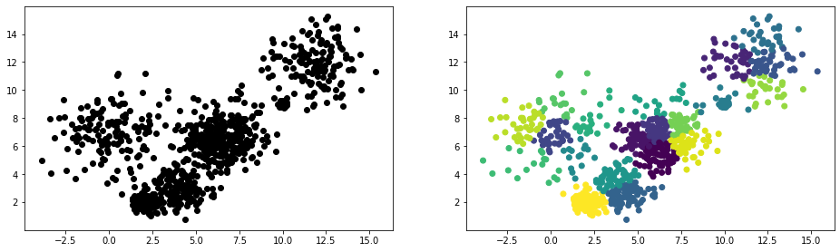

```python
import numpy as np
from sklearn.model_selection import train_test_split
from sklearn.cluster import KMeans
from sklearn.datasets.samples_generator import make_blobs
from sklearn import metrics
import matplotlib.pyplot as plt
from sklearn.cluster import AffinityPropagation
from functools import reduce

fig=plt.figure(figsize=(16,10))

x,y = make_blobs(n_samples=1000,n_features=4,centers=[[0,7],[2,2],[4,3],[6,6],[7,7],[10,9],[12,12]],cluster_std=[1.7,0.4,0.9,1.0,1.2,0.1,1.4],random_state=10)

#model= KMeans(n_clusters=4, random_state=10)

model = AffinityPropagation(damping=0.9)

model.fit(x)

y_predict = model.predict(x)


kind,count=np.unique(model.labels_,return_counts=True)
print(kind)
print(count)
print(sum(count))

p1=fig.add_subplot(221)
plt.scatter(x[:,0],x[:,1],c="black")

p2=fig.add_subplot(222)
plt.scatter(x[:,0],x[:,1],c=y_predict)



print(model.predict((x[:30,:])))
print(metrics.calinski_harabasz_score(x,y_predict))
print(model.cluster_centers_)
print(model.inertia_)
print(metrics.silhouette_score(x,y_predict))
```

Questions and problems: 应用领域的分析？ 动态抽样，兼顾过程的稳定性， 变异能力过程评价 过程能力，信息系统， 嵌入执行。部分产品 打通来料到过程 SPC MSA 嵌入到可靠性？

主线： 产品改进为主线，质量持续提升。 切入点：质量痛点？ 哪些？

数据基础薄弱，元数据状态？ 现有数据资源目标导向，有哪些目标可以完成闭环？

蒋部长提出双路径，以及路径相关资源的依赖程度： 路径1： 信息化系统关联。 路径2： 标准化数据。 以及必须要做的工作： 基于元数据状态，确定分析维度与准确度。 维度对应的准确度（confusion matrix）。元数据状态和方法同步寻找？ 划定范围。

讨论目的： 确定目标：突破头脑风暴法对对应维度无数据支撑的状态，无法对下一步质量问题解决对应的资源投入方向和方式。 讨论产出：流程（数据成熟度）与算法（对应目标确定方式和参数）。

绕不过的点：

元数据状态 算法准确率数反推据利用率，（可以反推， 出具成熟度标准。 但是准确率提升程度评估不了。模拟数据解决不了Y。）

产品和项点分类（X量级， 执行范围？）

资源和产品。目标是针对资源配置还是产品改善？数据源工作人员工作方式改善？

```python
from pyclust import KMedoids
import numpy as np
from sklearn.manifold import TSNE
import matplotlib.pyplot as plt
```